# BIOST 561: pkgdown

Lecture 9

# Announcements

- There was a bit snafu with HW4 and final project due dates
  - HW4 is due **MONDAY**, June 9th. (Not this upcoming Monday)
  - Final project is due **FRIDAY**, June 13th.
- The final project is posted. It is to make a PkgDown website, and the “submission” is to simply send me an email (kzlin@uw.edu) containing the URL of your PkgDown website.
  - I will confirm the receipt of your PkgDown with a reply of the email. If I don’t respond within 24 hours, **PLEASE EMAIL ME AGAIN**.

# Plan for today

- Go over setting up the simulation setup on Bayes (starting from scratch just in it’s helpful)
- Go over HW4
- Finish these slides (some quick things about using Bayes, then PkgDown, and with any remaining time, GitHub.io)

# A few more extra things about managing jobs

Suppose your job number is `340347` (which you learn after running `squeue --me`)

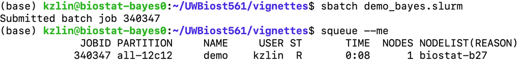

- How to cancel your jobs
  - If you realize you ran a job that’s already run a second time by accident
  - If you realize that after you started a job, there’s a typo that will kill your job in the future

```
scancel 340347
```

- How to check how much memory your job took

```
sacct -j 340347 --format=JobID,JobName,MaxRSS,MaxRSSNode%15
```

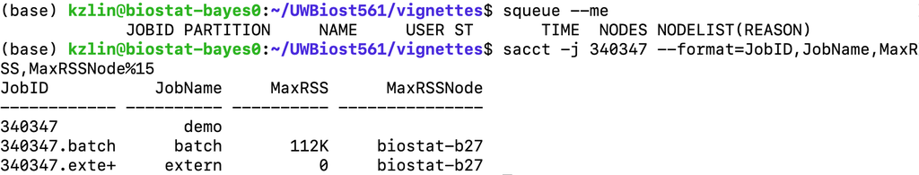

- In this screenshot, we can see that our job took `112K` (i.e., 112 Kilobytes, or 0.1 Megabytes) to complete.

Therefore, the usual workflow is this:

- When you are running a job on Bayes, a good initial estimate of how much memory you need to request (the `10gb` in `#SBATCH --mem-per-cpu=10gb` in your `.slurm` script) is: the size of your largest dataset your script analyzes multiplied by 5. (R is not very effecient with its memory.) If you are ever unsure, `10gb` is always a safe place to start.
  - This number should be larger than what you really need (since your job will get terminated prematurely if it actually needs more memory than you request), but not too execessively large (or else you’ll be griefing someone else who wants to use the server)
- Then, after your job runs and completes, use the above `sacct -j [[JOB-ID]] --format=JobID,JobName,MaxRSS,MaxRSSNode%15` line to see how much memory your job **actually** used.
- Based on this, adjust your `#SBATCH --mem-per-cpu=10gb` to be more accurate. Usually, you want to pad the amount of memory your job actually used by 10%-25% (just to be on the safe side).

# PkgDown

It’s honestly much easier than you might realize. All the steps you need is at https://pkgdown.r-lib.org/articles/pkgdown.html.

You need the `usethis` and `pkgdown` packages, and all you need to do is run the following lines to get a local (i.e., on your laptop) working version of your package.

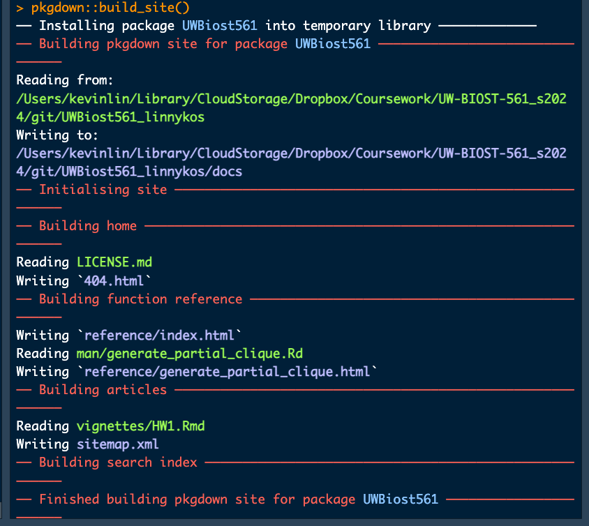

```r
# Make sure your package is all set to go first
devtools::check()

# Run once to configure package to use pkgdown
usethis::use_pkgdown()
# After running this, a file called "_pkgdown.yml" might open.
# You can save and close it.

# Run to build the website
pkgdown::build_site()
# The local version of your website might open up.
```

# A few notes

- `pkgdown` will try to literally rebuild all your vignettes – specifically the `.Rmd` files under the `vignettes` folder. So please make sure your vignettes can be compiled and do not load any local files (`.RData`, `.rds`, `.csv`, etc.).
- Before you go onto the next step, if your R package is associated with a GitHub page, things might go smoother if your GitHub repository is set to Public.

[figure not shown]

# Pushing your website to GitHub to have a PkgDown website

Let’s say you’re happy with the local-version of your PkgDown website. Then, to have the PkgDown website online,

- First, make sure your R package is the only thing for a Git repository, and that the Git repository is on GitHub. (Essentially, make sure you can view your package on GitHub.com.)
- Then, run the following line.

```r
usethis::use_pkgdown_github_pages()
```

- You might get a prompt that asks you if you want to overwrite `_pkgdown.yml`. Say yes.

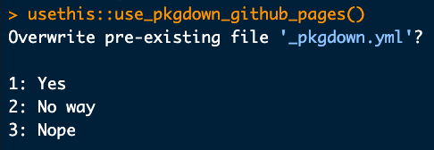

- Then, a whole bunch of things will start happening

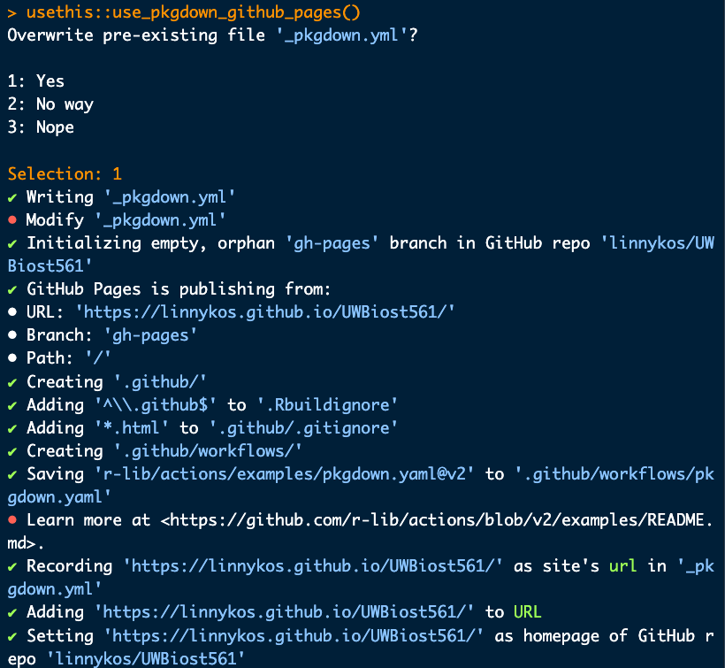

- Then, push your new Git repository from your laptop onto GitHub. (There will be a lot of new files. Just push it all.)
- On GitHub.com, you should now see a curious circle next to your commit message. (If you pushed your package just a minute ago, this will be an orange circle that says “pending”. If it’s been a few minutes and nothing bad happened, it’ll be a green checkmark that says “success”. If you see a red circle/cross, it means you have an error in your R package setup – you either messed with the PkgDown files too much, or your R package didn’t pass `devtools::check()` originally.)

[figure not shown]

- If you click on the orange circle (“pending”) while it’s still there, you will be brought to the “Actions” page

[figure not shown]

- This shows you that GitHub.com (i.e., servers run by GitHub) are currently recompiling your R package (importantly, re-running the vignettes) to build your website. This is why it’s important to be attentive that your vignettes have no errors and it doesn’t require any local files.
- Once you see a green checkmark next to your commit, you’re all set to go!

[figure not shown]

- If you didn’t mess with the settings, if your username is `linnykos` and your package’s name is `UWBiost561`, this means your PkgDown website is at `https://linnykos.github.io/UWBiost561/`.

[figure not shown]

- Congratulations!

# Some basic things you help your PkgDown website

You can refer to our course’s example PkgDown website https://linnykos.github.io/561_s2025_example/ (and the corresponding GitHub repository, https://github.com/linnykos/561_s2025_example) to see some things to make your website easier to navigate or more useful

- Create a `README.md` file. This goes next to `DESCRIPTION` file in your R package. This file could say some simple things:
  - Put the URL of both your GitHub repository (ex: https://github.com/linnykos/561_s2025_example) and your PkgDown website (ex: https://linnykos.github.io/561_s2025_example/). This is so people can easily navigate between both
  - Put the output of your `devtools::session_info()` so other users know exactly what your R setup was when you developed the package
- Under the `vignettes` folder, create a new vignette that **specifically** is named after your package. For example, if your package is named `UWBiost561`, this vignette must be specifically named `UWBiost561.Rmd`. When you construct your Pkgdown website, this vignette will **not** go under “Articles”, but instead, under “Get started.”
  - Typically, this vignette contains instructions on how to install your package (for example, using `devtools::install_github()`) and how to run a simple demo.

After you make any changes, be sure to re-run `devtools::check()` (to make sure your package is still in good condition) and then `pkgdown::build_site()`. Once both these functions run smoothly and complete, you can push your changes to GitHub, let GitHub rebuild your website, and then you’re good to go!

# More advance PkgDown things…

Please see the following pages for more customize options for your PkgDown website:

- https://pkgdown.r-lib.org/articles/customise.html
- https://psyteachr.github.io/intro-r-pkgs/07-pkgdown.html

# Setting up a GitHub Page (i.e., Github.io page)

Switching gears. Onto your personal website!

See https://docs.github.com/en/pages/quickstart. Follow the directions until the end of “Creating your website”.

- Your website is its own (new) GitHub repository
- To see how these websites were built, type in: https://github.com/[[github username]]/[[github username]].github.io.
- For example, https://github.com/linnykos/linnykos.github.io
- Pick a page whose layout you like, visit these Github.io pages.
- If you like a layout, visit the repository itself to find all the files used the create the page.
- Then, download all the files and put it in your repository, and start changing all the content to be your owns. (Be sure to give credit!)

# Examples of Github.io pages

Some simple templates to take (mainly just an `index.html` file):

- https://linnykos.github.io/
- https://zji90.github.io/
- https://frkoehle.github.io/
- https://zhimeir.github.io/

Most common template: https://academicpages.github.io/

- https://gqi.github.io/
- https://ekatsevi.github.io/
- https://larrylehan.github.io/
- https://mcelentano.github.io/
- https://yingma0107.github.io/

Some additional options:

- https://anna-neufeld.github.io/
- https://yezhengstat.github.io/
- https://rdevito.github.io/web/
- https://satarupa3671.github.io/
- https://lsn235711.github.io/
- https://jichunxie.github.io/index.html

# With the remaining time…

- Next lecture is the last class.
  - Finish today’s lecture
  - Discuss some interesting simulation results in HW4
  - Setting up Python and using ChatGPT to learn Python

# Additional links for using Bayes

- Companion Google Docs for Linux commands and using Bayes
  - https://docs.google.com/document/d/1369bf2WE7n2FzhFoqUv2rgWMZRurYfjHmGMUNHfOWBU/edit?usp=sharing
- Debugging
  - https://adv-r.hadley.nz/debugging.html
- Cheatsheet for Git commands
  - https://education.github.com/git-cheat-sheet-education.pdf
- Cheatsheet for Linux commands
  - https://phoenixnap.com/kb/wp-content/uploads/2023/11/linux-commands-cheat-sheet-pdf.pdf
  - The most useful commands are the ones under “Directory Navigation” and Files”
- Cheatsheat for SLURM commands
  - https://www.carc.usc.edu/user-information/user-guides/hpc-basics/slurm-cheatsheet

# Additional links for PkgDown

- https://www.youtube.com/watch?v=IRtOORWdKGI: This YouTube video contains essentially all the steps you need to follow
- https://pkgdown.r-lib.org/articles/pkgdown.html
- https://www.r-bloggers.com/2017/08/building-a-website-with-pkgdown-a-short-guide/